# simPop - symulowanie populacji

## czyli krótka relacja z *eRum 2016* - european R users meeting October 12-14, 2016 in Poznan, Poland

Pełnen program eRum jest tutaj -> (eRum BOOK OF ABSTRACTS).

Myślę, że najciekawsza z naszego (socjologicznego) punktu widzenia była prezentacja dotycząca pakiety "simPop":

| **Dzień 3 konferencji** | **14.10** |
| --- | --- |
| **Panel:** | **"Invited Talks V"** |
| **Prezentacja:** | **"Simulation of complex synthetic data with the R package simPop"** |
| **Wygłosił:** | **Matthias Templ, Vienna University of Technology** |

"simPop" służy do generowania populaji na podstawie zadanych rozkładów zmiennych / wyników sondaży.

Poniżej prezentacja kilku dostępnych opcji.

## Ładowanie pakietu simPop

Autorzy projektu (generalnie panowie z Wiednia):

Bernhard Meindl, Matthias Templ, Andreas Alfons, Alexander Kowarik, and with contributions from Mathieu Ribatet (2016). simPop: Simulation of Synthetic Populations for Survey Data Considering Auxiliary Information. R package version 0.3.0. URL http://CRAN.R-project.org/package=simPop.

```r
library("simPop")
```

## Ładowanie zbioru danych '*eusilcS*' z pakietu simPop

```r
data("eusilcS") # Synthetic EU-SILC survey data
```

Dane ze zbioru *eusilcS*:

```r
head( eusilcS)
```

|  | db030 | hsize | db040 | age | rb090 | pl030 | pb220a | netIncome | py010n | py050n | py090n | py100n | py110n | py120n | py130n | py140n | db090 | rb050 |
| --- | --- | --- | --- | --- | --- | --- | --- | --- | --- | --- | --- | --- | --- | --- | --- | --- | --- | --- |
| 9292 | 1 | 2 | Salzburg | 72 | male | 5 | AT | 22675.48 | 0.00 | 0 | 0 | 22675.48 | 0 | 0 | 0.00 | 0 | 7.822929 | 7.822929 |
| 9293 | 1 | 2 | Salzburg | 66 | female | 5 | AT | 16999.29 | 0.00 | 0 | 0 | 0.00 | 0 | 0 | 16999.29 | 0 | 7.822929 | 7.822929 |
| 7227 | 2 | 1 | Upper Austria | 56 | female | 2 | AT | 19274.21 | 19274.21 | 0 | 0 | 0.00 | 0 | 0 | 0.00 | 0 | 8.788089 | 8.788089 |
| 5275 | 3 | 1 | Styria | 67 | female | 5 | AT | 13319.13 | 0.00 | 0 | 0 | 13319.13 | 0 | 0 | 0.00 | 0 | 8.108452 | 8.108452 |
| 7866 | 4 | 3 | Upper Austria | 70 | female | 5 | AT | 14365.57 | 0.00 | 0 | 0 | 14365.57 | 0 | 0 | 0.00 | 0 | 7.509383 | 7.509383 |
| 7867 | 4 | 3 | Upper Austria | 46 | male | 3 | AT | 0.00 | 0.00 | 0 | 0 | 0.00 | 0 | 0 | 0.00 | 0 | 7.509383 | 7.509383 |

## Generowanie obiektu klasy ’*dataObj*’ - dane wsadowe

Obiekty klasy **’*dataObj*’ służą do przechowywani danych wsadowych (samych rozkładów brzegowych albo całych prób z sondaży)**, które mają poslużyć **do generowania populacji**. W poniższym przykładzie dane wsadowe to dane z badania ankietowego - zbiór *eusilcS* .Na jego podstawie wygenerowana zostanie populacji.

```
* hhid - nazwa zmienne w zbiorze oznaczająca numer identyfikacyjny obserwacji;
* weight - nazwa wagi w zbiorze;
* strata - nazwa zmiennej oznaczającej warstwy.
```

```r
inp <- specifyInput(data=eusilcS, hhid="db030", weight="rb050", strata="db040")
class(inp)
```

'dataObj'

```r
inp
```

```
 --------------
survey sample of size 11725 x 20

 Selected important variables:

 household ID: db030
 personal ID: pid
 variable household size: hhsize
 sampling weight: rb050
 strata: db040
 --------------
```

## Generowanie populacji na podstawie danych wsadowych

Dane wsatdowe w tym przypadku to zbiór *inp* ale równie dobrze mogą to być same rozkłady brzegowe.

Popilację generuje się przy pomocy funkcji *simStructure*. Opis użytych argumentów:

- data - dane wsadowe klasy 'dataObj'
- method - metoda symulacji:
  - "direct" (estimation of the population totals for each combination of stratum and household size using the Horvitz-Thompson estimator)
  - "multinom" (estimation of the conditional probabilities within the strata using a multinomial log-linear model and random draws from the result-ing distributions)
  - "distribution" (random draws from the observed conditional distributions within the strata)
- basicHHvars - nazwy zmiennych, które mają się znaleźć w zbiorze wynikowym

```r
eusilcP <- simStructure(data=inp, method="direct", basicHHvars=c("age", "rb090", "netIncome"))
class(eusilcP)
eusilcP
```

'simPopObj'

```
--------------
synthetic population  of size
 81838 x 8

build from a sample of size
11725 x 20
--------------

variables in the population:
db030,hhsize,db040,age,rb090,netIncome,pid,weight
```

## Prezentacja wyników przy pomocy funkcji '*spBwplot*'

Argumenty funkcji '*spBwplot*':

- inp - obiekt klasy 'simPopObj'
- x - nazwa zmiennej która ma zostać zaprezentowana
- cond - opcjonalnie nazwa zmiennej względem której ma zostać utworzony wykres warunkowy.

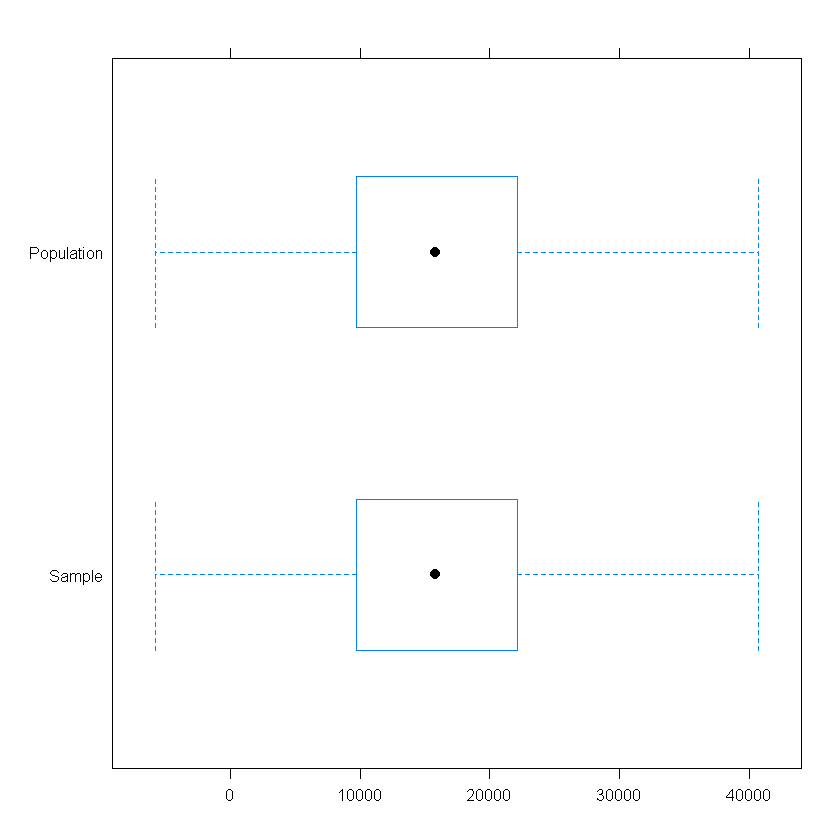

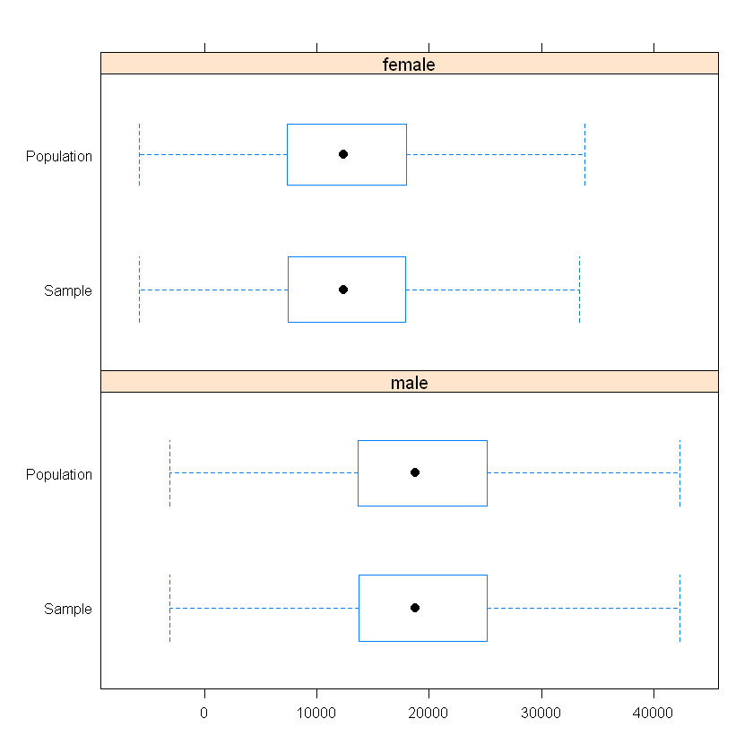

```r
spBwplot(eusilcP, x="netIncome", cond=NULL)
spBwplot(eusilcP, x="netIncome", cond="rb090", layout=c(1,2))
```

## Podsumowanie

*simPop* wydaje się dosyć ograniczony. Może to wynika z mojego niezrozumienia tego pakietu ale wyobrażałem sobie to trochę inaczej. Miałem nadzieję, że simPop będzie pozwalał bardziej swobodnie manipulować wynikową populacją. Nie rozumiem po co stworzono specjalną klasę obiektów simPopObj - to niepotrzebna komplikacja. Jeśli okaże się, że simPop rzeczywiście pozwala generować populacje o dowolnych cechach to super - tego potrzebowaliśmy. W przeciwnym wypadku będzie to piękny przykład marnotrawienia funduszy grantowych na budowanie nikomu nieprzydatnych pakietów.